# Supercell Data Analysis Project

### **Report is at the end of the notebook**

#### by Emir Dinc - https://www.linkedin.com/in/emir-dinc/

## Explaratory Data Analysis

Importing neccesary libraries to use in our data analysis

```python
import pandas as pd
import numpy as np
import matplotlib.pyplot as plt
import seaborn as sns
import plotly.express as px
import sqlite3
```

Establishing a connection to our SQLite database and loading the data from the **`account`, `account_date_session`, and `iap_purchase`** tables into separate pandas DataFrames

```python
conn = sqlite3.connect('/Users/emirdinc/Downloads/sample.sqlite')
account_df = pd.read_sql_query("SELECT * FROM account", conn)
account_date_session_df = pd.read_sql_query("SELECT * FROM account_date_session", conn)
iap_purchase_df = pd.read_sql_query("SELECT * FROM iap_purchase", conn)
```

### Account Table

```python
account_df
```

|  | account_id | created_time | created_device | created_platform | country_code | created_app_store_id |
| --- | --- | --- | --- | --- | --- | --- |
| 0 | 13514010 | 2016-03-02 17:11:00.332 | iPhone6,2 | iOS | GB | 1 |
| 1 | 4308483975 | 2016-03-02 20:57:46.14 | MIDC147PJ | Android | FR | 2 |
| 2 | 17193137415 | 2016-03-02 13:52:16.735 | SM-G360F | Android | IT | 2 |
| 3 | 21488104920 | 2016-03-02 12:43:27.899 | H60-L01 | Android | CN | 8 |
| 4 | 21488107995 | 2016-03-02 17:20:12.145 | GT-I9500 | Android | RU | 2 |
| ... | ... | ... | ... | ... | ... | ... |
| 112787 | 51554039942 | 2016-08-07 13:32:49.115 | KOPO L128 | Android | CN | 4 |
| 112788 | 51554090637 | 2016-08-11 22:20:27.192 | SM-G3608 | Android | CN | 15 |
| 112789 | 51554102314 | 2016-08-12 21:10:20.742 | iPhone8,4 | iOS | US | 1 |
| 112790 | 51554116380 | 2016-08-14 01:37:13.821 | SM-G935F | Android | HR | 2 |
| 112791 | 51554126520 | 2016-08-14 19:31:45.436 | iPad3,1 | iOS | GB | 1 |

112792 rows × 6 columns

The account table contains the following columns:

- `account_id`: Unique identifier for the account
- `created_time`: Date and time when the account was created
- `created_device`: Device used to create the account
- `created_platform`: Platform used to create the account
- `country_code`: Country code of the country where the account was created
- `created_app_store_id`: An identifier for the app store which the account was created

```python
column_data_types = account_df.dtypes
print(column_data_types)
```

```
account_id              object
created_time            object
created_device          object
created_platform        object
country_code            object
created_app_store_id     int64
dtype: object
```

#### Data Validation and Cleaning

We want to convert the `created_time` column to a datetime object if we want to use it for analysis. We also want to check if there are any **NaN** values in the dataset

```python
account_df['created_time'] = pd.to_datetime(account_df['created_time'])
account_df['year'] = account_df['created_time'].dt.year
is_all_2016 = account_df['year'].eq(2016).all()

duplicate_account_ids = account_df['account_id'].duplicated().sum()

nan_check = account_df.isna().sum()
empty_string_check = (account_df == '').sum().sum()

print("All values are 2016:", is_all_2016)
print("Number of duplicate 'account_id' entries:", duplicate_account_ids)
print("Number of empty string values in DataFrame:", empty_string_check)
print("Number of NaN values in DataFrame:")
print(nan_check)
```

```
All values are 2016: True
Number of duplicate 'account_id' entries: 0
Number of empty string values in DataFrame: 0
Number of NaN values in DataFrame:
account_id                0
created_time              0
created_device            0
created_platform          0
country_code            107
created_app_store_id      0
year                      0
dtype: int64
```

- We have validated that all of the values are in the year of 2016.
- We have validated that we do not have any duplicate ids in our DataFrame.
- We have validated that we do not have any empty values in our DataFrame.
- We see that `account_df` has **NaN** values in the `country_code` column. We will replace these NaN values with the string **'Unknown'** to indicate that we do not know the country code for these accounts.

```python
account_df['country_code'].fillna('Unknown', inplace=True)
print("Number of NaN values in DataFrame:", account_df.isna().sum().sum())
```

```
Number of NaN values in DataFrame: 0
```

As we can see, we have cleaned our DataFrame and there is no more **NaN** values left

#### Further Analysis of our Account Table

##### I wanted to see how many OS platforms are there in our dataset. We can see that there are 2 different platforms in our dataset: iOS and Android with Android dominating the market share.

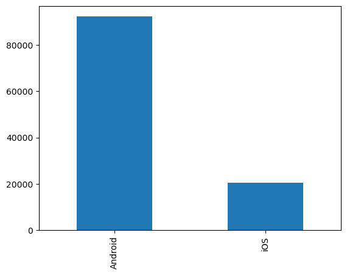

```python
value_counts_platform = account_df['created_platform'].value_counts()
value_counts_platform.plot.bar()
```

##### I wanted to see how many different devices we have in our dataset. We can see that there are 11,327 different devices in our dataset but the top 14 devices make up 15% of the total devices in our dataset, and these are mostly iOS devices.

```
iPhone7,2                2764
iPhone8,1                2206
iPhone6,2                1456
iPhone4,1                1182
iPhone7,1                1122
                         ...
Q03Note                     1
ZTE U930                    1
4114E                       1
NT-1071A                    1
Energy Tablet 9 Neo 2       1
Name: created_device, Length: 11327, dtype: int64
iPhone7,2    2.450528
iPhone8,1    1.955812
iPhone6,2    1.290872
iPhone4,1    1.047947
iPhone7,1    0.994751
iPhone8,2    0.938896
iPhone5,2    0.790836
iPad4,4      0.780197
iPad2,5      0.763352
iPhone6,1    0.737641
iPad4,1      0.687105
SM-G900F     0.682673
iPad5,3      0.672033
GT-I9500     0.660508
Name: created_device, dtype: float64
```

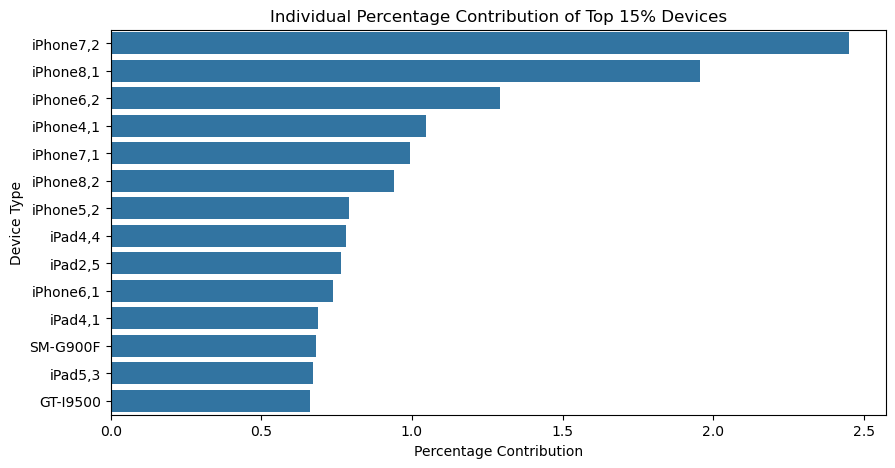

```python
value_counts_devices = account_df['created_device'].value_counts()
cumulative_percentage = value_counts_devices.cumsum() / value_counts_devices.sum()
top_values_15_percent = cumulative_percentage[cumulative_percentage <= 0.15]

total_entries = account_df['created_device'].count()
top_devices = value_counts_devices.loc[top_values_15_percent.index]
individual_percentages = (top_devices / total_entries) * 100


print(value_counts_devices)
print(individual_percentages)

plt.figure(figsize=(10, 5))
sns.barplot(x=individual_percentages.values, y=individual_percentages.index)
plt.title('Individual Percentage Contribution of Top 15% Devices')
plt.xlabel('Percentage Contribution')
plt.ylabel('Device Type')
```

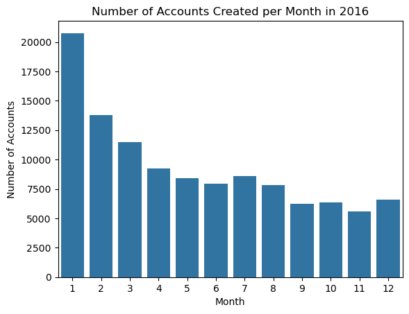

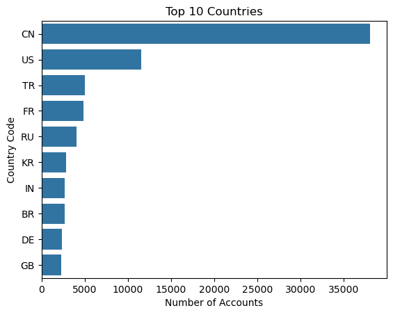

```python
account_df['created_time'] = pd.to_datetime(account_df['created_time'])
account_df['month'] = account_df['created_time'].dt.month
monthly_counts = account_df['month'].value_counts().sort_index()
sns.barplot(x=monthly_counts.index, y=monthly_counts.values)
plt.xlabel('Month')
plt.ylabel('Number of Accounts')
plt.title('Number of Accounts Created per Month in 2016')
plt.show()

top_countries = account_df['country_code'].value_counts().head(10)
sns.barplot(x=top_countries.values, y=top_countries.index)
plt.xlabel('Number of Accounts')
plt.ylabel('Country Code')
plt.title('Top 10 Countries')
plt.show()
```

### Account Date Session Table

```python
account_date_session_df
```

|  | account_id | date | session_count | session_duration_sec |
| --- | --- | --- | --- | --- |
| 0 | 68730811144 | 2016-01-01 | 1 | 47 |
| 1 | 68730812806 | 2016-01-01 | 1 | 204 |
| 2 | 68730829426 | 2016-01-01 | 12 | 4703 |
| 3 | 68730829426 | 2016-01-02 | 9 | 4676 |
| 4 | 68730829426 | 2016-01-03 | 9 | 2271 |
| ... | ... | ... | ... | ... |
| 1698969 | 55850490316 | 2016-12-30 | 1 | 392 |
| 1698970 | 55850515956 | 2016-12-30 | 1 | 564 |
| 1698971 | 55850515956 | 2016-12-31 | 9 | 3268 |
| 1698972 | 55850519336 | 2016-12-31 | 9 | 4043 |
| 1698973 | 55850528526 | 2016-12-31 | 1 | 202 |

1698974 rows × 4 columns

#### Explaratory Data Analysis

##### Looking at total session counts daily, weekly, and monthly. We can see that the daily session count is very volatile but there are interesting strikes and drops that is happening throughout the year. We can see that the weekly session count is more stable and it is increasing in the begeninning of the year and stayin steady for the most part until a noticable drop in September, ending the year wiht lowest session count since the beginning of the year. Monthly session count also shows a similar trend.

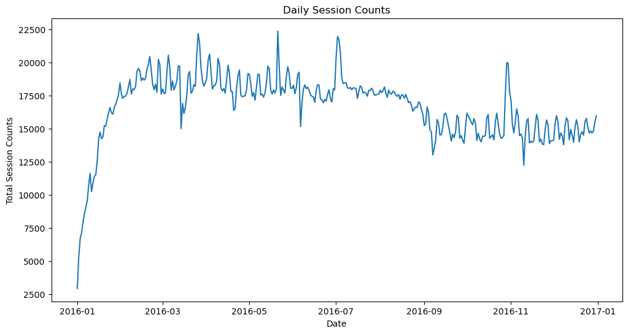

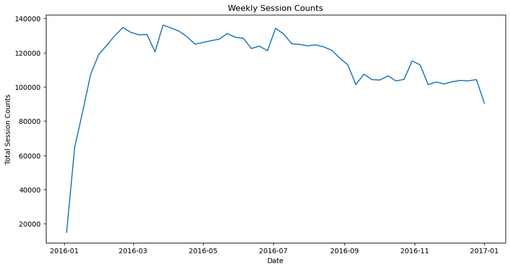

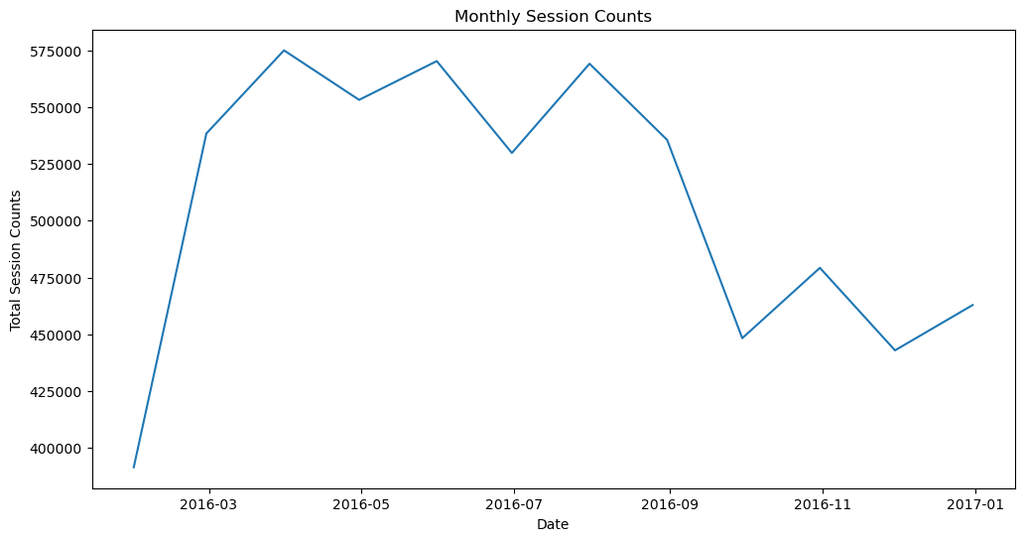

```python
account_date_session_df['date'] = pd.to_datetime(account_date_session_df['date'])
daily_sessions = account_date_session_df.groupby('date')['session_count'].sum()
weekly_sessions = account_date_session_df.resample('W', on='date')['session_count'].sum()
monthly_sessions = account_date_session_df.resample('M', on='date')['session_count'].sum()

plt.figure(figsize=(12, 6))
sns.lineplot(x=daily_sessions.index, y=daily_sessions.values)
plt.title('Daily Session Counts')
plt.xlabel('Date')
plt.ylabel('Total Session Counts')
plt.show()

plt.figure(figsize=(12, 6))
sns.lineplot(x=weekly_sessions.index, y=weekly_sessions.values)
plt.title('Weekly Session Counts')
plt.xlabel('Date')
plt.ylabel('Total Session Counts')
plt.show()

plt.figure(figsize=(12, 6))
sns.lineplot(x=monthly_sessions.index, y=monthly_sessions.values)
plt.title('Monthly Session Counts')
plt.xlabel('Date')
plt.ylabel('Total Session Counts')
plt.show()
```

- **End of October:** The dates 2016-10-29, 2016-10-30, and 2016-10-31 show very high average session durations. These dates align with Halloween, which suggests that special events or themed content may have driven increased engagement.
- **Early July:** The dates 2016-07-02 and 2016-07-03 coincide with a weekend and are near the U.S. Independence Day holiday. There could have been special events or promotions encouraging longer play sessions.
- **Late March:** The date 2016-03-26 is a Saturday and the day before Easter Sunday. Again, this could be indicative of holiday-related activities within the game.

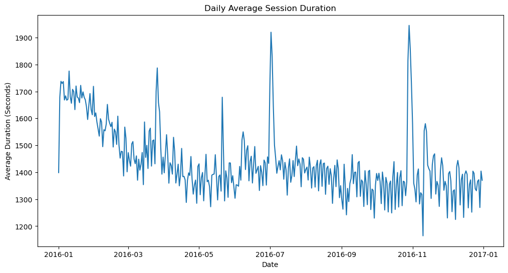

```python
daily_avg_duration = account_date_session_df.groupby('date')['session_duration_sec'].mean()

plt.figure(figsize=(12, 6))
sns.lineplot(x=daily_avg_duration.index, y=daily_avg_duration.values)
plt.title('Daily Average Session Duration')
plt.xlabel('Date')
plt.ylabel('Average Duration (Seconds)')
plt.show()
```

##### We see that there is a very high correlation (0.95) between the `session_count` and `session_duration` columns. This is a good sign, because this suggests that on days when there are more sessions (higher session counts), those sessions tend to be longer in duration as well, so our users are more engaged with the contents of the game.

```
Correlation between session count and duration: 0.9528519585476501
```

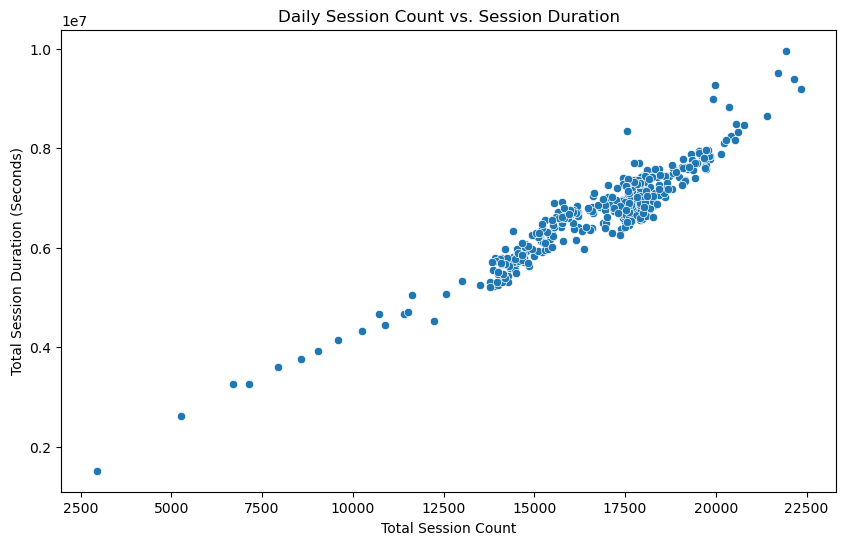

```python
daily_data = account_date_session_df.groupby('date').agg({'session_count': 'sum', 'session_duration_sec': 'sum'})

correlation = daily_data['session_count'].corr(daily_data['session_duration_sec'])

print(f"Correlation between session count and duration: {correlation}")

plt.figure(figsize=(10, 6))
sns.scatterplot(x='session_count', y='session_duration_sec', data=daily_data)
plt.title('Daily Session Count vs. Session Duration')
plt.xlabel('Total Session Count')
plt.ylabel('Total Session Duration (Seconds)')
plt.show()
```

#### Now onto the part where we analyze our Daily Active Users (DAU)

##### Our DAU is defined as the number of unique users who played the game on a given day. We can see that the DAU is very volatile and there are clearly trends to be explored here with a lot of spikes and drops throughout the year.

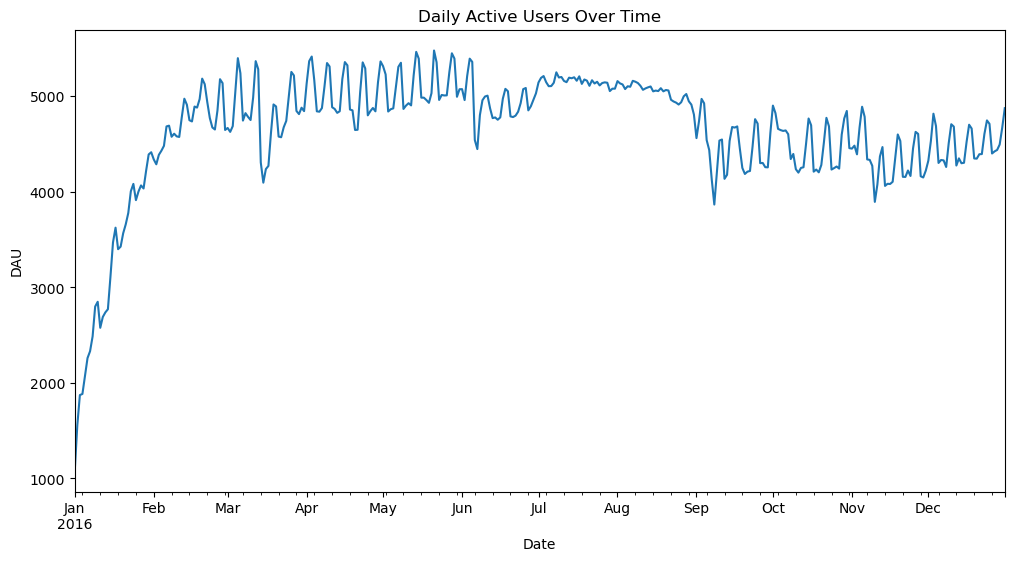

```python
dau = account_date_session_df.groupby('date')['account_id'].nunique()

plt.figure(figsize=(12, 6))
dau.plot(kind='line')
plt.title('Daily Active Users Over Time')
plt.xlabel('Date')
plt.ylabel('DAU')
plt.show()
```

##### In the analysis of DAU, we can see that there is a lot of volatility in the previous graph. To address this, I implemented a rolling mean and standard deviation to smooth out the graph which enabled me to see the trends more clearly with a clearer identification of spikes and drops. I picked a window size of 7 because to analyze the spikes and drops in each week more comprehensively since from our previous graph it seems to be indicating there is more activity over weekends. Additionally, I excluded January from the graph since a lot of accounts were signing up in January and it was skewing the graph.

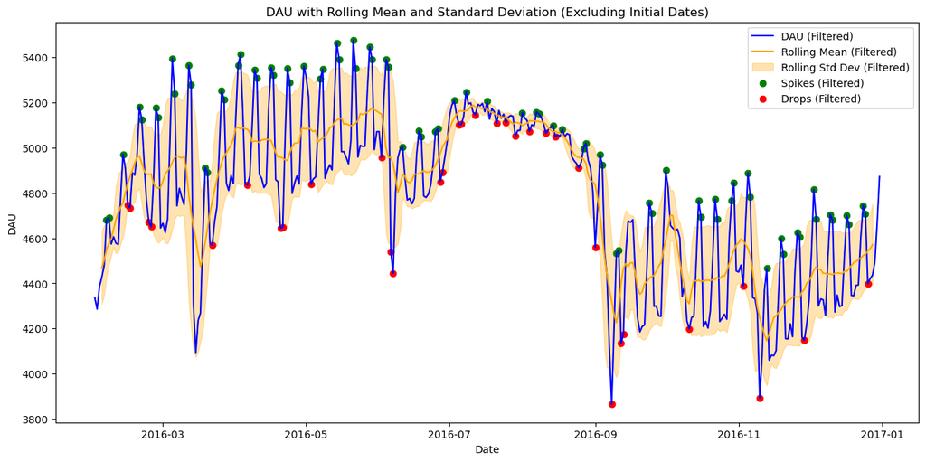

```python
cutoff_date = pd.to_datetime('2016-02-01')
filtered_df = account_date_session_df[account_date_session_df['date'] >= cutoff_date]

dau_filtered = filtered_df.groupby('date')['account_id'].nunique()

window_size = 7  # for a weekly pattern

rolling_mean_filtered = dau_filtered.rolling(window=window_size, center=True).mean()
rolling_std_filtered = dau_filtered.rolling(window=window_size, center=True).std()

spike_threshold_filtered = rolling_mean_filtered + rolling_std_filtered
drop_threshold_filtered = rolling_mean_filtered - rolling_std_filtered

spikes_filtered = dau_filtered[dau_filtered > spike_threshold_filtered]
drops_filtered = dau_filtered[dau_filtered < drop_threshold_filtered]

plt.figure(figsize=(15, 7))

plt.plot(dau_filtered, label='DAU (Filtered)', color='blue')

plt.plot(rolling_mean_filtered, label='Rolling Mean (Filtered)', color='orange')
plt.fill_between(rolling_mean_filtered.index, rolling_mean_filtered - rolling_std_filtered, rolling_mean_filtered + rolling_std_filtered, color='orange', alpha=0.3, label='Rolling Std Dev (Filtered)')

plt.scatter(spikes_filtered.index, spikes_filtered, label='Spikes (Filtered)', color='green')

plt.scatter(drops_filtered.index, drops_filtered, label='Drops (Filtered)', color='red')

plt.title('DAU with Rolling Mean and Standard Deviation (Excluding Initial Dates)')
plt.xlabel('Date')
plt.ylabel('DAU')
plt.legend()
plt.show()
```

##### As we can see our analysis does a good job of identifying spikes and drops but it doesn't seem to be identifying every spike and drop throughout the year and to make this analysis more robust we would need to do add a tighter threshold. In the next part I decided to implement a dynamic threshold to see if we can identify more spikes and drops. I defined spikes as values exceeding the rolling mean by 0.7 times the rolling standard deviation and drops as values falling below the mean by the same factor.

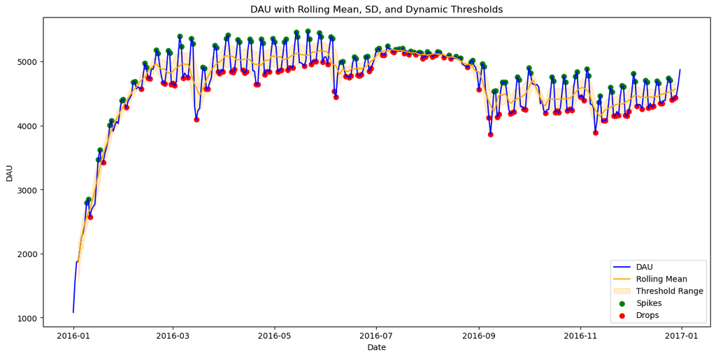

```python
rolling_mean = dau.rolling(window=window_size, center=True).mean()
rolling_std = dau.rolling(window=window_size, center=True).std()

upper_threshold = rolling_mean + 0.7 * rolling_std
lower_threshold = rolling_mean - 0.7 * rolling_std

spikes = dau[dau > upper_threshold]
drops = dau[dau < lower_threshold]

plt.figure(figsize=(15, 7))
plt.plot(dau, label='DAU', color='blue')
plt.plot(rolling_mean, label='Rolling Mean', color='orange')
plt.fill_between(rolling_mean.index, upper_threshold, lower_threshold, color='orange', alpha=0.2, label='Threshold Range')
plt.scatter(spikes.index, spikes, label='Spikes', color='green')
plt.scatter(drops.index, drops, label='Drops', color='red')
plt.title('DAU with Rolling Mean, SD, and Dynamic Thresholds')
plt.xlabel('Date')
plt.ylabel('DAU')
plt.legend()
plt.show()
```

##### As we can see our graph looks way more robust in identifying every significant drop and spike in our data and lastly we need to drop the month of january to be able to have a better look at these trends.

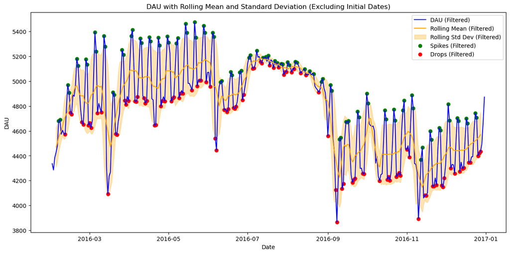

```python
spike_threshold_filtered = rolling_mean_filtered + 0.7 * rolling_std_filtered
drop_threshold_filtered = rolling_mean_filtered - 0.7 * rolling_std_filtered

spikes_filtered = dau_filtered[dau_filtered > spike_threshold_filtered]
drops_filtered = dau_filtered[dau_filtered < drop_threshold_filtered]

plt.figure(figsize=(15, 7))

plt.plot(dau_filtered, label='DAU (Filtered)', color='blue')

plt.plot(rolling_mean_filtered, label='Rolling Mean (Filtered)', color='orange')
plt.fill_between(rolling_mean_filtered.index, rolling_mean_filtered - rolling_std_filtered, rolling_mean_filtered + rolling_std_filtered, color='orange', alpha=0.3, label='Rolling Std Dev (Filtered)')

plt.scatter(spikes_filtered.index, spikes_filtered, label='Spikes (Filtered)', color='green')

plt.scatter(drops_filtered.index, drops_filtered, label='Drops (Filtered)', color='red')

plt.title('DAU with Rolling Mean and Standard Deviation (Excluding Initial Dates)')
plt.xlabel('Date')
plt.ylabel('DAU')
plt.legend()
plt.show()
```

```python
print(spikes_filtered)
```

```
date
2016-02-06    4682
2016-02-07    4690
2016-02-13    4972
2016-02-14    4909
2016-02-20    5182
              ...
2016-12-11    4680
2016-12-17    4700
2016-12-18    4660
2016-12-24    4745
2016-12-25    4709
Name: account_id, Length: 94, dtype: int64
```

```python
print(drops_filtered)
```

```
date
2016-02-11    4572
2016-02-15    4747
2016-02-16    4734
2016-02-24    4671
2016-02-25    4650
              ...
2016-12-19    4347
2016-12-20    4345
2016-12-26    4399
2016-12-27    4421
2016-12-28    4436
Name: account_id, Length: 103, dtype: int64
```

### IAP Purchase Table

```python
iap_purchase_df
```

|  | account_id | created_time | package_id_hash | iap_price_usd_cents | app_store_id |
| --- | --- | --- | --- | --- | --- |
| 0 | 30077202816 | 2016-03-26 23:59:59.355 | ae0253c27c34edd1ab4fe21d6bfc91f8 | 739 | 0 |
| 1 | 30077202816 | 2016-05-31 11:24:37.283 | dd4c1bda4f2c904075fb2fbfcf30f30e | 369 | 0 |
| 2 | 21487283560 | 2016-02-13 03:40:28.644 | 99a9e0e63efa2fdce8fc8de74c66cea9 | 184 | 0 |
| 3 | 21487152816 | 2016-02-28 00:53:26.678 | 99a9e0e63efa2fdce8fc8de74c66cea9 | 184 | 0 |
| 4 | 8602037685 | 2016-02-11 01:03:04.727 | 99a9e0e63efa2fdce8fc8de74c66cea9 | 184 | 0 |
| ... | ... | ... | ... | ... | ... |
| 9904 | 51552698769 | 2016-07-23 03:25:58.87 | 99a9e0e63efa2fdce8fc8de74c66cea9 | 184 | 1 |
| 9905 | 51552698769 | 2016-07-25 05:57:33.827 | 99a9e0e63efa2fdce8fc8de74c66cea9 | 184 | 1 |
| 9906 | 51552698769 | 2016-11-14 01:01:11.202 | efd2eebfdc98b55f9e6b45915d56f7ac | 36 | 1 |
| 9907 | 51552698769 | 2016-12-02 13:43:30.761 | efd2eebfdc98b55f9e6b45915d56f7ac | 36 | 1 |
| 9908 | 64436338850 | 2016-10-09 01:42:58.696 | efd2eebfdc98b55f9e6b45915d56f7ac | 36 | 16 |

9909 rows × 5 columns

#### Explaratory Data Analysis

##### - We merge the purchase table with the account table to get the country code for each purchase in a new DataFrame called `sales_data`.

##### - We convert `iap_price_usd_cents` to usd dollars by dividing it by 100.

##### - We aggregate the data by country code and sum the total revenue for each country in a new DataFrame called `revenue_by_country`.

##### - We can see that the top 10 countries by revenue are United States, China, South Korea, Canada, Turkey, Switzerland, France, United Kingdom, Germany, and Colombia.

##### - It is also important to note that these top 10 countries make up 94% of the total revenue.

```
country_code
US    13148.18
CN    11365.07
KR     4635.18
CA     2545.06
TR     1933.39
CH     1827.74
FR     1527.39
GB     1450.86
DE      946.21
CO      458.60
Name: iap_price_usd, dtype: float64
country_code
US    30.923346
CN    26.729630
KR    10.901530
CA     5.985754
TR     4.547161
CH     4.298681
FR     3.592285
GB     3.412293
DE     2.225401
CO     1.078586
Name: iap_price_usd, dtype: float64
Top 10 countries account for 93.69% of total revenue.
```

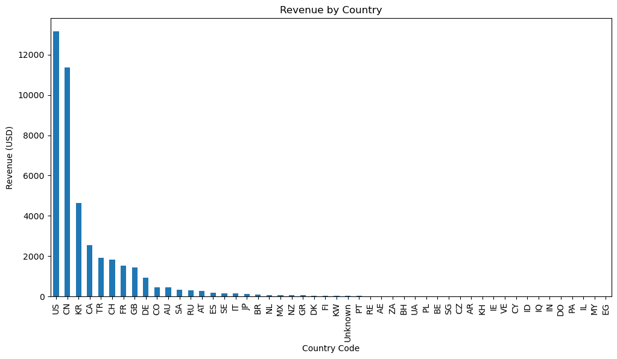

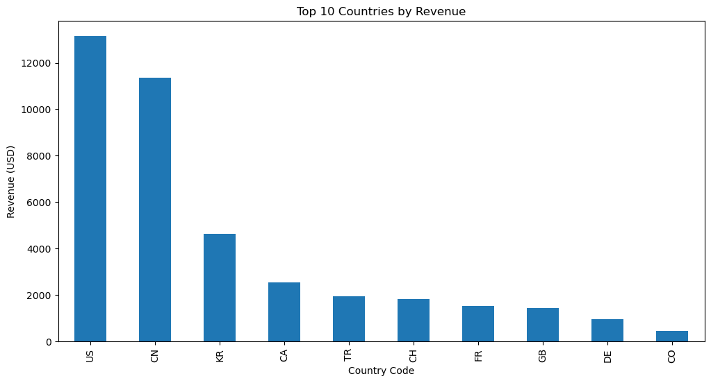

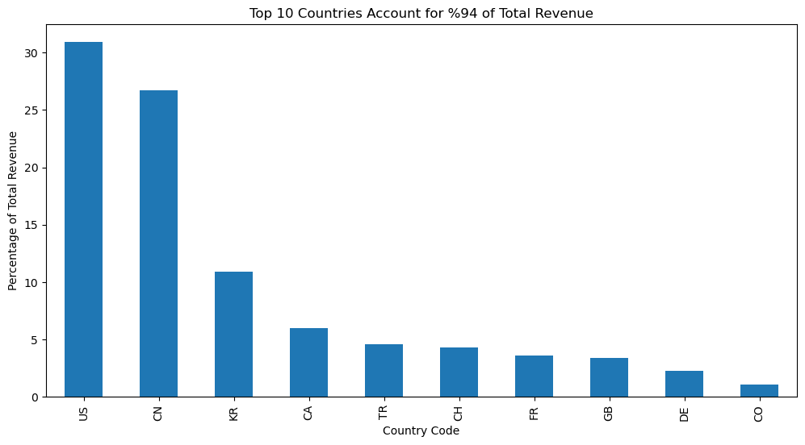

```python
sales_data = pd.merge(iap_purchase_df, account_df[['account_id', 'country_code']], on='account_id', how='left')

sales_data['iap_price_usd'] = sales_data['iap_price_usd_cents'] / 100

revenue_by_country = sales_data.groupby('country_code')['iap_price_usd'].sum()

top_10_revenue_by_country = revenue_by_country.sort_values(ascending=False).head(10)
print(top_10_revenue_by_country)

total_revenue = revenue_by_country.sum()
top_10_revenue_percentage = (top_10_revenue_by_country / total_revenue) * 100
print(top_10_revenue_percentage)
print("Top 10 countries account for {:.2f}% of total revenue.".format(top_10_revenue_percentage.sum()))

plt.figure(figsize=(12, 6))
revenue_by_country.sort_values(ascending=False).plot.bar()
plt.title('Revenue by Country')
plt.xlabel('Country Code')
plt.ylabel('Revenue (USD)')
plt.xticks(rotation=90)

plt.show()

plt.figure(figsize=(12, 6))
top_10_revenue_by_country.sort_values(ascending=False).plot.bar()
plt.title('Top 10 Countries by Revenue')
plt.xlabel('Country Code')
plt.ylabel('Revenue (USD)')
plt.xticks(rotation=90)
plt.show()

plt.figure(figsize=(12, 6))
top_10_revenue_percentage.sort_values(ascending=False).plot.bar()
plt.title('Top 10 Countries Account for %94 of Total Revenue')
plt.xlabel('Country Code')
plt.ylabel('Percentage of Total Revenue')
plt.xticks(rotation=90)
plt.show()
```

##### - We then calculate the number of unique users per country using the `sales_data` DataFrame and aggregate the data by country code in a new DataFrame called `unique_users_by_country`.

##### - We then merge the `revenue_by_country` and `unique_users_by_country` DataFrames to get the average revenue per user for each country in a new DataFrame called `arpu_by_country`.

```python
unique_users_per_country = sales_data.groupby('country_code')['account_id'].nunique()

arpu_per_country = revenue_by_country / unique_users_per_country
```

##### - After that we sort the countries by their average revenue per user, and visualize it in a bar chart.

```
country_code
CO    458.600000
AT    284.710000
CH    203.082222
TR     96.669500
KR     64.377500
NZ     60.930000
CA     60.596667
US     53.016855
JP     46.803333
ES     35.162000
dtype: float64
```

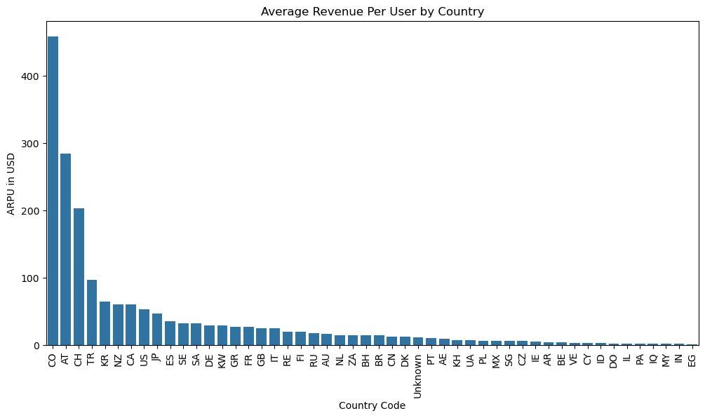

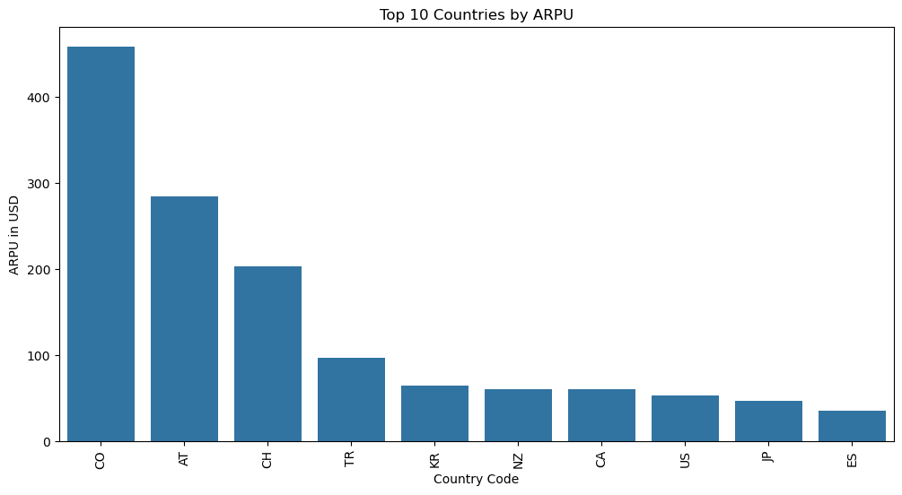

```python
sorted_arpu_per_country = arpu_per_country.sort_values(ascending=False)

print(sorted_arpu_per_country.head(10))

plt.figure(figsize=(12, 6))
sns.barplot(x=sorted_arpu_per_country.index, y=sorted_arpu_per_country.values)
plt.title('Average Revenue Per User by Country')
plt.xlabel('Country Code')
plt.ylabel('ARPU in USD')
plt.xticks(rotation=90)
plt.show()

plt.figure(figsize=(12, 6))
sns.barplot(x=sorted_arpu_per_country.head(10).index, y=sorted_arpu_per_country.head(10).values)
plt.title('Top 10 Countries by ARPU')
plt.xlabel('Country Code')
plt.ylabel('ARPU in USD')
plt.xticks(rotation=90)
plt.show()
```

##### - We create a new DataFrame called `market_comparison` which contains `Unique Users` and `Average Revenue Per User` columns for each country, and we have interesting findings which I'll discuss in the report.

```
              Unique_Users        ARPU
country_code
CO                       1  458.600000
AT                       1  284.710000
CH                       9  203.082222
TR                      20   96.669500
KR                      72   64.377500
NZ                       1   60.930000
CA                      42   60.596667
US                     248   53.016855
JP                       3   46.803333
ES                       5   35.162000
SE                       5   32.840000
SA                      10   32.092000
DE                      32   29.569063
KW                       1   29.540000
GR                       2   27.715000
FR                      56   27.274821
GB                      57   25.453684
IT                       6   25.383333
RE                       1   20.330000
FI                       2   20.305000
RU                      17   17.707059
AU                      26   17.333077
NL                       5   15.196000
ZA                       1   14.780000
BH                       1   14.750000
BR                       6   14.330000
CN                     874   13.003513
DK                       4   12.440000
Unknown                  2   11.985000
PT                       2   11.055000
AE                       2    9.765000
KH                       1    7.380000
UA                       2    7.365000
PL                       2    6.995000
MX                       9    6.962222
SG                       2    6.450000
CZ                       2    6.445000
IE                       1    5.520000
AR                       2    4.600000
BE                       3    4.303333
VE                       1    3.690000
CY                       1    3.680000
ID                       1    3.680000
DO                       1    1.840000
IL                       1    1.840000
PA                       1    1.840000
IQ                       2    1.840000
MY                       1    1.840000
IN                       1    1.840000
EG                       1    1.100000
```

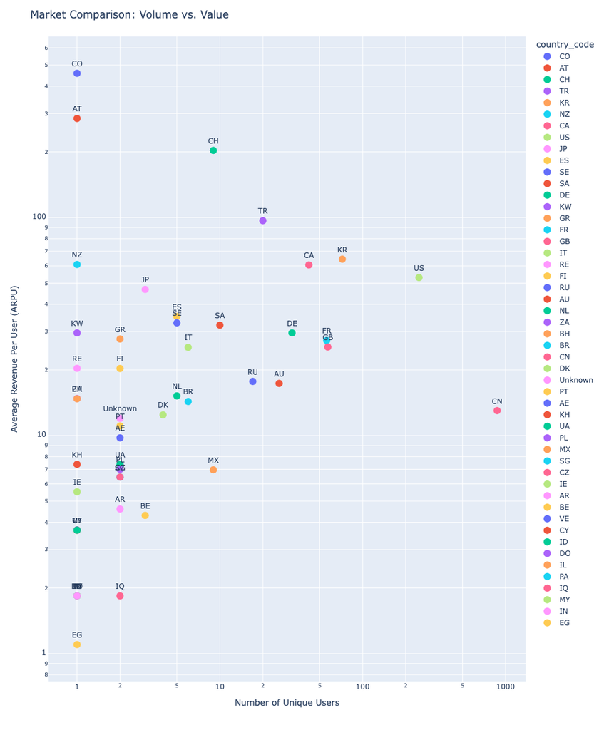

```python
market_comparison = pd.DataFrame({
    'Unique_Users': unique_users_per_country,
    'ARPU': arpu_per_country
}).sort_values(by='ARPU', ascending=False)

print(market_comparison)

fig = px.scatter(market_comparison, x='Unique_Users', y='ARPU', text=market_comparison.index, color=market_comparison.index, log_x=True, log_y=True)
fig.update_traces(textposition='top center', marker=dict(size=12))
fig.update_layout(title='Market Comparison: Volume vs. Value', xaxis_title='Number of Unique Users', yaxis_title='Average Revenue Per User (ARPU)', width=1200, height=1200)
fig.show()
```

## **Report**

### 1) Dataset Descriptions

The database for analysis contains three tables, each providing unique insights into user behavior and revenue generation for our mobile game throughout the year of 2016. Here is an overview of each table:

#### `account`

This table serves as the backbone of user-related data, containing profiles for each user. The key attributes include:

- `account_id`: The unique identifier for each user.
- `created_time`: The timestamp for when the account was created.
- `created_device`: The device model used for account creation.
- `created_platform`: The operating system of the device (iOS and Android).
- `country_code`: The country code representing the user's location at account creation.
- `created_app_store_id`: Identifier for the app store through which the account was created.

#### `account_date_session`

This table tracks the daily engagement of users, with details on the sessions they've played the game. It includes:

- `account_id`: The unique identifier correlating to the `account` table.
- `date`: The date of the user's activity.
- `session_count`: The total number of sessions the user had on the given date.
- `session_duration_sec`: The total duration of the user's sessions in seconds on the given date.

#### `iap_purchase`

The in-app purchase table records the transactions made by users within the game. It contains:

- `account_id`: Linking back to the `account` table to associate purchases with users.
- `created_time`: Timestamp for when the purchase was made.
- `package_id_hash`: An anonymized identifier for the purchased item or package.
- `iap_price_usd_cents`: The price of the in-app purchase in US cents.
- `app_store_id`: Identifier for the app store through which the purchase was made.

### 2) Daily Acitivity of Users (DAU)

***Quoting from my analysis***

Our `DAU` is defined as the number of unique users who played the game on a given day. We can see that the DAU is very `volatile` and there are clearly trends to be explored here with a lot of spikes and drops throughout the year. To address this, I implemented a rolling mean and standard deviation to smooth out the graph which enabled me to see the trends more clearly with a clearer identification of spikes and drops. I picked a `window size` of **7** to analyze the spikes and drops in each week more comprehensively since from our `DAU` graph there seems to be more activity over weekends. Additionally, I excluded January from the graph since a lot of accounts were signing up in January and it was skewing the graph. My initial analysis did a good job of identifying spikes and drops but it didn't seem to be identifying every spike and drop throughout the year and to make this analysis more robust I would need to add a tighter threshold. In the next part, I decided to implement a `dynamic threshold` to see if we can identify more spikes and drops. I defined spikes as values exceeding the rolling mean by **0.7** times the rolling standard deviation and drops as values falling below the mean by the same factor. At the end my graph looked way more robust in identifying every significant drop and spike in our data, and here are the findinds from my analysis:

#### `Spikes:`

- **Weekend Trends:**

A significant number of these top spikes occur on weekends (Saturdays and Sundays). I think this is due to the nature of Supercell games being targeted towards a younger audience who are most likely still in school and generally have more free time during the weekends.

- **Summer Months Trends:** I observed several spikes during the summer months (June, July, and August). During summer, users might have more leisure time, because of summer holidays for schools and colleges occur during these months.
- **Holiday Season Trends:** Late December dates, like 2016-12-24 (Christmas Eve) and 2016-12-25 (Christmas Day), show increased activity, likely due to the holiday season and when Supercell most likely be running special events or promotions.

#### `Drops:`

- **Weekdays and Non-Holiday Trends:** Many of the dates with drops fall on weekdays or periods not associated with major holidays. This pattern suggests that user activity in the game tends to be lower on typical workdays or school days when users might have less free time for gaming.
- **Post-Holiday Trends:**

Some dates that show a drop in session counts follow a holiday or special event. For example, 2016-07-05 is right after the U.S. Independence Day holiday, and the drop might indicate a return to routine after the holiday. This trend also reflects a pattern where users are highly active during holidays and then return to normal activity levels afterward.

- **Seasonal Factors:**

Certain months, particularly late summer and autumn months (September, October), show more frequent drops. This could be due to seasonal factors such as the start of the academic year or end of vacation periods, which might reduce the amount of time users have for gaming.

### 3) Sales Analysis

Let's talk about the geographic variation in ARPU which comes from our findings from the the scatter plot which gives us a visual representation of the relationship between the number of users and ARPU in each market. I used logarithmic scales to make it easier to identify patterns and outliers:

- **High ARPU in Smaller Markets:** Some countries with a very small user base (e.g., Colombia, Austria, Switzerland) have extremely high ARPU. This could suggest that although the user base is limited in these countries, the users who are engaged are spending significantly more.
- **Moderate to High ARPU in Key Markets:** Countries like the US, Canada, and South Korea, despite having a larger number of users, still maintain a relatively high ARPU. This indicates that these countries are key markets for Supercell, with a large user base and high spending.
- **Lower ARPU in Large Markets:** Some countries with a large user base, like China (CN), show lower ARPU. This could be due to a variety of factors, such as lower spending power in these countries or a less engaged user base. It could also not hurt to consider economic factors/restricitons in these regions.

### End of Report - Thank you for taking the time to read my analysis! Hope to hear from you soon!

### Stay Awesome! 😎 - Emir Dinc